# lab1

Cristopher Barrios, Josue Sagastume

21/7/2023

### 1. Haga una exploración rápida de sus datos.

```r
df = read.csv("./risk_factors_cervical_cancer.csv")
```

```r
# Crear un nuevo DataFrame seleccionando solo las columnas deseadas
nuevo_df <- data.frame(
  Age = df$Age,
  Number_of_sexual_partners = as.numeric(df$Number.of.sexual.partners),
  First_sexual_intercourse = as.numeric(df$First.sexual.intercourse),
  Num_of_pregnancies = as.numeric(df$Num.of.pregnancies),
  Smokes = as.numeric(df$Smokes),
  Hormonal_Contraceptives = as.numeric(df$Hormonal.Contraceptives),
  IUD = as.numeric(df$IUD),
  STDs = as.numeric(df$STDs),
  Dx_Cancer = df$Dx.Cancer,
  Dx_HPV = df$Dx.HPV,
  Biopsy = df$Biopsy
)

# Opcionalmente, puedes renombrar las columnas si deseas utilizar nombres más cortos
colnames(nuevo_df) <- c("Age", "Number_of_sexual_partners", "First_sexual_intercourse",
                        "Num_of_pregnancies", "Smokes", "Hormonal_Contraceptives",
                        "IUD", "STDs", "Dx_Cancer", "Dx_HPV", "Biopsy")
```

```r
library(readr)
library(dplyr)
data <- read_csv('risk_factors_cervical_cancer.csv')
data <- data %>% mutate_all(~replace(., . == "?", NA))


missing_values <- colSums(is.na(data))


numerical_stats <- data %>% summarise(across(where(is.numeric), list(mean = mean, std_dev = sd, min = min, max = max)))


categorical_stats <- data %>% summarise(across(where(is.character), list(unique = ~length(unique(.)), most_common = ~names(which.max(table(.))))))
```

```r
missing_values
```

```
##                                Age          Number of sexual partners
##                                  0                                 26
##           First sexual intercourse                 Num of pregnancies
##                                  7                                 56
##                             Smokes                     Smokes (years)
##                                 13                                 13
##                Smokes (packs/year)            Hormonal Contraceptives
##                                 13                                108
##    Hormonal Contraceptives (years)                                IUD
##                                108                                117
##                        IUD (years)                               STDs
##                                117                                105
##                      STDs (number)                STDs:condylomatosis
##                                105                                105
##       STDs:cervical condylomatosis        STDs:vaginal condylomatosis
##                                105                                105
## STDs:vulvo-perineal condylomatosis                      STDs:syphilis
##                                105                                105
##   STDs:pelvic inflammatory disease                STDs:genital herpes
##                                105                                105
##         STDs:molluscum contagiosum                          STDs:AIDS
##                                105                                105
##                           STDs:HIV                   STDs:Hepatitis B
##                                105                                105
##                           STDs:HPV          STDs: Number of diagnosis
##                                105                                  0
##   STDs: Time since first diagnosis    STDs: Time since last diagnosis
##                                787                                787
##                          Dx:Cancer                             Dx:CIN
##                                  0                                  0
##                             Dx:HPV                                 Dx
##                                  0                                  0
##                         Hinselmann                           Schiller
##                                  0                                  0
##                           Citology                             Biopsy
##                                  0                                  0
```

```r
#numerical_stats
#categorical_stats
```

```r
summary(nuevo_df)
```

```
##       Age        Number_of_sexual_partners First_sexual_intercourse
##  Min.   :13.00   Min.   : 1.000            Min.   :10
##  1st Qu.:20.00   1st Qu.: 2.000            1st Qu.:15
##  Median :25.00   Median : 2.000            Median :17
##  Mean   :26.82   Mean   : 2.528            Mean   :17
##  3rd Qu.:32.00   3rd Qu.: 3.000            3rd Qu.:18
##  Max.   :84.00   Max.   :28.000            Max.   :32
##                  NA's   :26                NA's   :7
##  Num_of_pregnancies     Smokes       Hormonal_Contraceptives      IUD
##  Min.   : 0.000     Min.   :0.0000   Min.   :0.0000          Min.   :0.000
##  1st Qu.: 1.000     1st Qu.:0.0000   1st Qu.:0.0000          1st Qu.:0.000
##  Median : 2.000     Median :0.0000   Median :1.0000          Median :0.000
##  Mean   : 2.276     Mean   :0.1456   Mean   :0.6413          Mean   :0.112
##  3rd Qu.: 3.000     3rd Qu.:0.0000   3rd Qu.:1.0000          3rd Qu.:0.000
##  Max.   :11.000     Max.   :1.0000   Max.   :1.0000          Max.   :1.000
##  NA's   :56         NA's   :13       NA's   :108             NA's   :117
##       STDs          Dx_Cancer           Dx_HPV            Biopsy
##  Min.   :0.0000   Min.   :0.00000   Min.   :0.00000   Min.   :0.0000
##  1st Qu.:0.0000   1st Qu.:0.00000   1st Qu.:0.00000   1st Qu.:0.0000
##  Median :0.0000   Median :0.00000   Median :0.00000   Median :0.0000
##  Mean   :0.1049   Mean   :0.02098   Mean   :0.02098   Mean   :0.0641
##  3rd Qu.:0.0000   3rd Qu.:0.00000   3rd Qu.:0.00000   3rd Qu.:0.0000
##  Max.   :1.0000   Max.   :1.00000   Max.   :1.00000   Max.   :1.0000
##  NA's   :105
```

```r
# Ver las primeras filas del nuevo DataFrame
head(nuevo_df)
```

```
##   Age Number_of_sexual_partners First_sexual_intercourse Num_of_pregnancies
## 1  18                         4                       15                  1
## 2  15                         1                       14                  1
## 3  34                         1                       NA                  1
## 4  52                         5                       16                  4
## 5  46                         3                       21                  4
## 6  42                         3                       23                  2
##   Smokes Hormonal_Contraceptives IUD STDs Dx_Cancer Dx_HPV Biopsy
## 1      0                       0   0    0         0      0      0
## 2      0                       0   0    0         0      0      0
## 3      0                       0   0    0         0      0      0
## 4      1                       1   0    0         1      1      0
## 5      0                       1   0    0         0      0      0
## 6      0                       0   0    0         0      0      0
```

### 2. Diga el tipo de cada una de las variables del dataset (cualitativa o categórica, cuantitativa continua, cuantitativa discreta

#### Cuantitativas discretas:

STDs (number), Age, Number of sexual partners, STDs: Number of diagnosis, Num of pregnancies

#### Cuantitativas continuas:

First sexual intercourse, STDs: Time since last diagnosis, STDs: Time since first diagnosis, Smokes (years), Smokes (packs/year), IUD (years), Hormonal Contraceptives (years)

#### Cualitativas:

STDs:cervical condylomatosis, Schiller, STDs:HPV, IUD, STDs:vulvo-perineal condylomatosis, STDs, STDs:syphilis, Dx:HPV, Dx:Cancer, STDs:HIV, STDs:molluscum contagiosum, STDs:condylomatosis, Dx:CIN, Hinselmann, STDs:Hepatitis B, Hormonal Contraceptives, Biopsy, Citology, STDs:genital herpes, STDs:vaginal condylomatosis, Dx, STDs:AIDS, Smokes

### 3. Incluya los gráficos exploratorios siendo consecuentes con el tipo de variable que están representando.

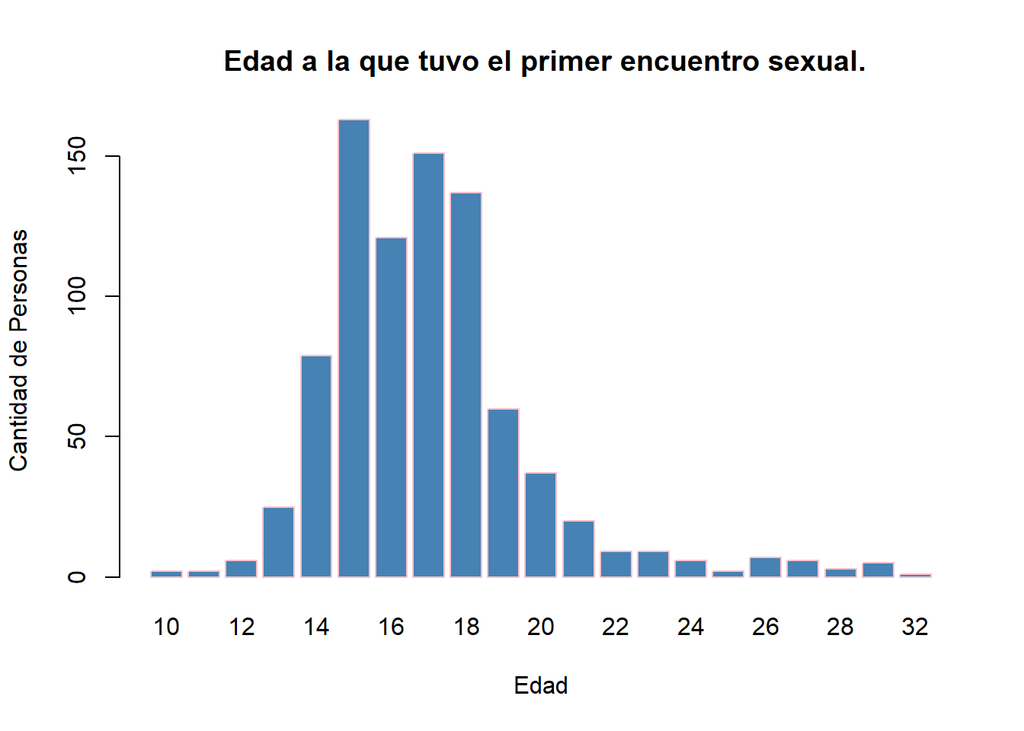

```r
barplot(table(nuevo_df$First_sexual_intercourse), main = " Edad a la que tuvo el primer encuentro sexual.", xlab = "Edad", ylab = "Cantidad de Personas", col = "steelblue" , border = "pink")
```

La mayoria de las personas en este conjunto de datos tienensu primer encuentro sexual entre los 14 años hasta los 20

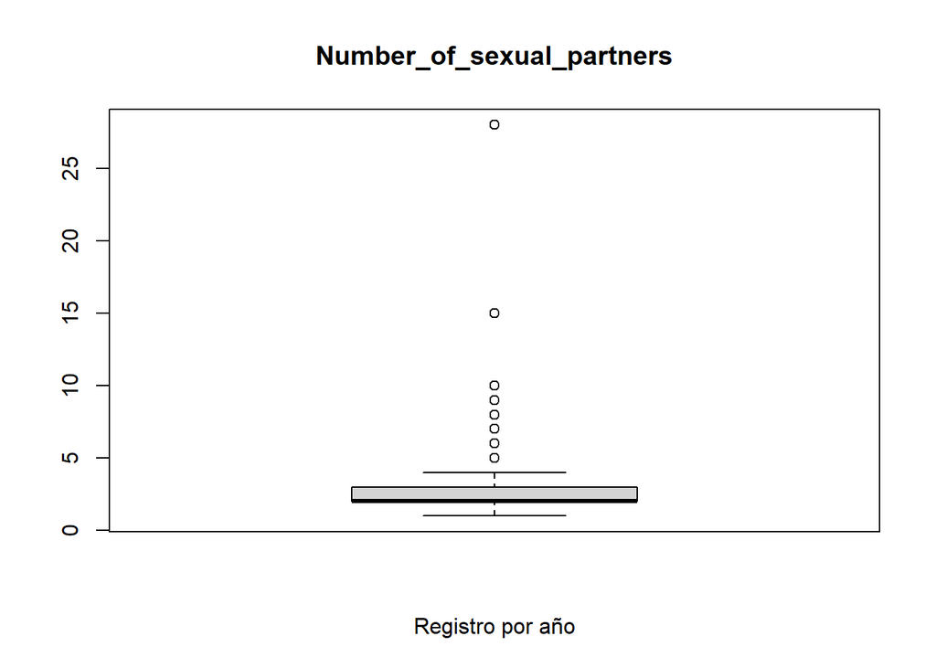

```r
boxplot(nuevo_df$Number_of_sexual_partners, main = "Number_of_sexual_partners", xlab = "Registro por año")
```

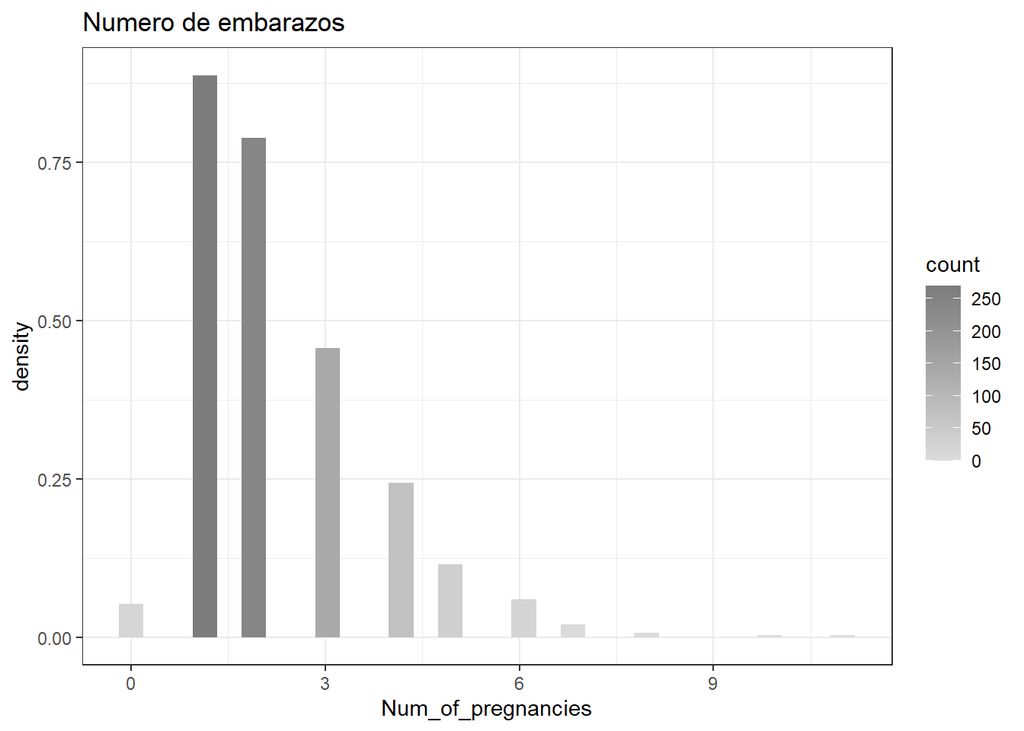

```r
# Cargar el paquete ggplot2
library(ggplot2)

ggplot(data = nuevo_df, aes(x = Num_of_pregnancies)) +
  geom_histogram(aes(y=..density.., fill = ..count..))+
  scale_fill_gradient(low = "#DCDCDC", high = "#7C7C7C")+
  stat_function(fun = dnorm, colour = "firebrick",
                args = list(mean = mean(nuevo_df$Num_of_pregnancies),
                            sd = sd(nuevo_df$Num_of_pregnancies)))+
  ggtitle("Numero de embarazos ") +
  theme_bw()
```

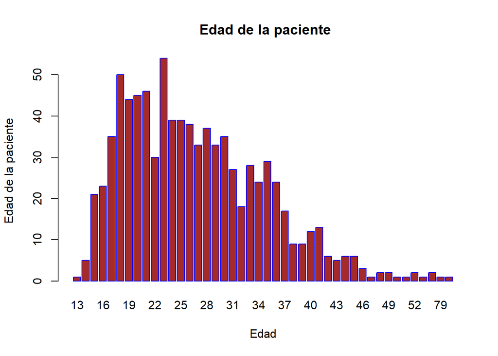

```r
barplot(table(nuevo_df$Age), main = " Edad de la paciente", xlab = "Edad", ylab = "Edad de la paciente", col = "brown" , border = "blue")
```

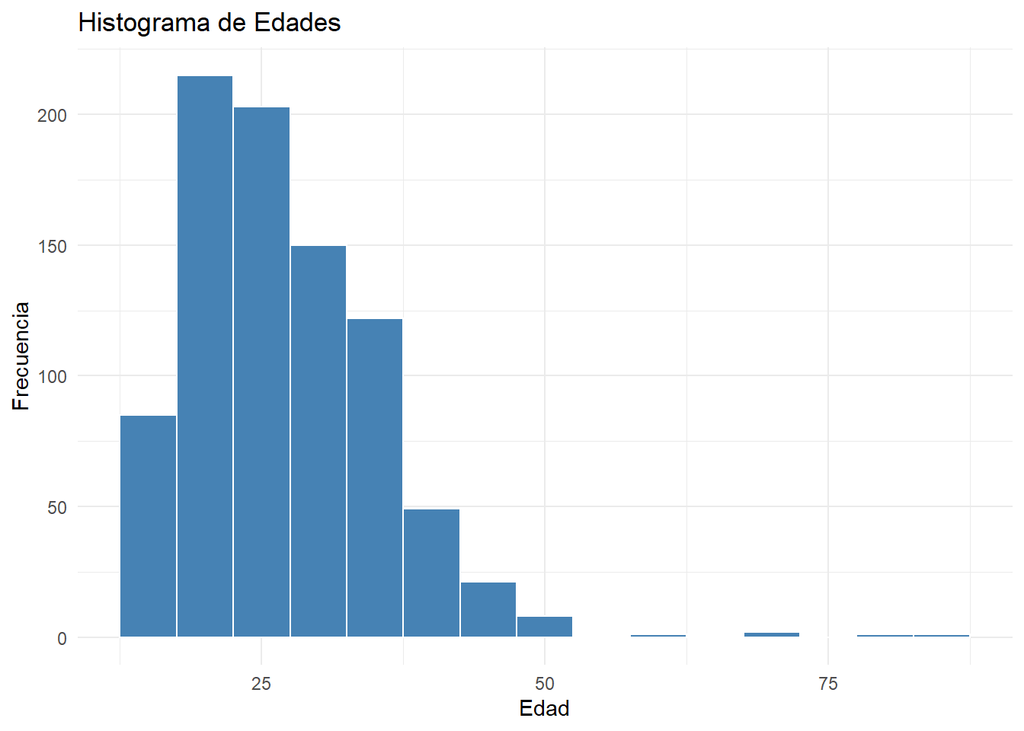

```r
ggplot(df, aes(x = Age)) +
  geom_histogram(binwidth = 5, fill = "steelblue", color = "white") +
  labs(title = "Histograma de Edades", x = "Edad", y = "Frecuencia") +
  theme_minimal()
```

Este histograma de edades podemos observar que llega gente muy joven a este sitio por diferentes enfermedades, y la adulta casi no llega.

[figure not shown]

```r
ggplot(df, aes(x = `Smokes..years.`)) +
  geom_density(fill = "steelblue", alpha = 0.5) +
  labs(title = "Densidad de Años Fumando", x = "Años Fumando", y = "Densidad") +
  theme_minimal()
```

[figure not shown]

```r
ggplot(df, aes(x = `Age`, y = `Number.of.sexual.partners`)) +
  geom_point(color = "steelblue", size = 3) +
  labs(title = "Gráfico de Dispersión: Edad vs Cantidad de Parejas Sexuales",
       x = "Edad", y = "Cantidad de Parejas Sexuales") +
  theme_minimal()
```

### 4. Aísle las variables numéricas de las categóricas, haga un análisis de correlación entre las mismas.

```r
df <- read.csv("./risk_factors_cervical_cancer.csv")

library(dplyr)
library(corrr)



library(FactoMineR)
library(fpc)
library(factoextra)
```

```r
library(corrplot)
#df <- read.csv("./data/Ejemplo.csv", stringsAsFactors = FALSE)

#¿Reemplazar '?' con NA (valores faltantes)
df[df == "?"] <- NA

# ¿onvertir las columnas especificadas a numéricas
numeric_columns <- c('Age','Number.of.sexual.partners', 'First.sexual.intercourse', 'Num.of.pregnancies',
                     'Smokes..years.', 'Smokes..packs.year.', 'Hormonal.Contraceptives..years.',
                     'IUD..years.', 'STDs..number.')

df[numeric_columns] <- lapply(df[numeric_columns], as.numeric)

# ¿ Seleccionar solo las columnas numéricas y crear la matriz de correlación
numeric_data <- df[, sapply(df, is.numeric)]
#correlation_matrix <- correlate(numeric_data, method = "pearson")

# Imprimir la matriz de correlación
#print(correlation_matrix)

cor(numeric_data[,-1],use = "pairwise.complete.obs")
```

```
##                                 Number.of.sexual.partners
## Number.of.sexual.partners                     1.000000000
## First.sexual.intercourse                     -0.150168584
## Num.of.pregnancies                            0.079080651
## Smokes..years.                                0.186932306
## Smokes..packs.year.                           0.182066838
## Hormonal.Contraceptives..years.               0.019569271
## IUD..years.                                   0.004453860
## STDs..number.                                 0.041441676
## STDs..Number.of.diagnosis                     0.051899624
## Dx.Cancer                                     0.022316365
## Dx.CIN                                        0.015693534
## Dx.HPV                                        0.027272910
## Dx                                            0.022991951
## Hinselmann                                   -0.039847408
## Schiller                                     -0.008966946
## Citology                                      0.021857561
## Biopsy                                       -0.001442452
##                                 First.sexual.intercourse Num.of.pregnancies
## Number.of.sexual.partners                   -0.150168584        0.079080651
## First.sexual.intercourse                     1.000000000       -0.060732749
## Num.of.pregnancies                          -0.060732749        1.000000000
## Smokes..years.                              -0.058834446        0.180330830
## Smokes..packs.year.                         -0.056755203        0.100903857
## Hormonal.Contraceptives..years.              0.008307764        0.224790029
## IUD..years.                                 -0.026503290        0.154987170
## STDs..number.                                0.006745144        0.001743902
## STDs..Number.of.diagnosis                   -0.013331999        0.034153312
## Dx.Cancer                                    0.067288505        0.035149052
## Dx.CIN                                      -0.032627759        0.010985120
## Dx.HPV                                       0.043969587        0.046788003
## Dx                                           0.035754625        0.021335813
## Hinselmann                                  -0.016548708        0.040438701
## Schiller                                     0.003494755        0.092017287
## Citology                                    -0.010973152       -0.030036158
## Biopsy                                       0.007264369        0.046415929
##                                 Smokes..years. Smokes..packs.year.
## Number.of.sexual.partners          0.186932306         0.182066838
## First.sexual.intercourse          -0.058834446        -0.056755203
## Num.of.pregnancies                 0.180330830         0.100903857
```

[output cut: 89 more lines]

```
## Num.of.pregnancies              -0.030036158  0.046415929
## Smokes..years.                  -0.006827071  0.062044187
## Smokes..packs.year.              0.004665534  0.024881930
## Hormonal.Contraceptives..years.  0.076263187  0.079387633
## IUD..years.                      0.002714703  0.033275306
## STDs..number.                    0.060009521  0.098347334
## STDs..Number.of.diagnosis        0.055114464  0.097448921
## Dx.Cancer                        0.113446079  0.160904975
## Dx.CIN                          -0.023937652  0.113172334
## Dx.HPV                           0.113446079  0.160904975
## Dx                               0.088739964  0.157606644
## Hinselmann                       0.192467108  0.547416628
## Schiller                         0.361486486  0.733203881
## Citology                         1.000000000  0.327466388
## Biopsy                           0.327466388  1.000000000
```

Esta tabla muestra los coeficientes de correlación, que varían entre -1 y 1, y reflejan la dirección y la intensidad de la asociación lineal entre pares de variables. Un coeficiente de correlación positivo cercano a 1 indica una relación directamente proporcional, lo que significa que a medida que una variable aumenta, la otra también tiende a aumentar. Por otro lado, un coeficiente negativo cercano a -1 denota una relación inversamente proporcional, indicando que a medida que una variable aumenta, la otra tiende a disminuir. Un coeficiente cercano a 0 sugiere que no hay una asociación lineal aparente entre las variables. La tabla de correlación es valiosa para identificar posibles patrones y tendencias entre variables, lo que permite una comprensión más profunda de la interacción entre los datos y guía el proceso de toma de decisiones en diversas áreas.

### 5. Utilice las variables categóricas, haga tablas de frecuencia, proporción, gráficas de barras o cualquier otra técnica que le permita explorar los datos.

```r
# Categorías de las variables cualitativas
categorias_cualitativas <- c("STDs.cervical.condylomatosis", "Schiller", "STDs.HPV", "IUD", "STDs.vulvo.perineal.condylomatosis", "STDs", "STDs.syphilis", "Dx.HPV", "Dx.Cancer", "STDs.HIV", "STDs.molluscum.contagiosum", "STDs.condylomatosis", "Dx.CIN", "Hinselmann", "STDs.Hepatitis.B", "Hormonal.Contraceptives", "Biopsy", "Citology", "STDs.genital.herpes", "STDs.vaginal.condylomatosis", "Dx", "STDs.AIDS", "Smokes")

tablas_frecuencias_cualitativas <- lapply(categorias_cualitativas, function(var) table(df[[var]]))

for (i in seq_along(tablas_frecuencias_cualitativas)) {
  cat("Tabla de frecuencias para la variable:", categorias_cualitativas[i], "\n")
  print(tablas_frecuencias_cualitativas[[i]])
  cat("\n")
}
```

```
## Tabla de frecuencias para la variable: STDs.cervical.condylomatosis
##
## 0.0
## 753
##
## Tabla de frecuencias para la variable: Schiller
##
##   0   1
## 784  74
##
## Tabla de frecuencias para la variable: STDs.HPV
##
## 0.0 1.0
## 751   2
##
## Tabla de frecuencias para la variable: IUD
##
## 0.0 1.0
## 658  83
##
## Tabla de frecuencias para la variable: STDs.vulvo.perineal.condylomatosis
##
## 0.0 1.0
## 710  43
##
## Tabla de frecuencias para la variable: STDs
##
## 0.0 1.0
## 674  79
##
## Tabla de frecuencias para la variable: STDs.syphilis
##
## 0.0 1.0
## 735  18
##
## Tabla de frecuencias para la variable: Dx.HPV
##
##   0   1
## 840  18
##
```

[output cut: 59 more lines]

```
##
## Tabla de frecuencias para la variable: Dx
##
##   0   1
## 834  24
##
## Tabla de frecuencias para la variable: STDs.AIDS
##
## 0.0
## 753
##
## Tabla de frecuencias para la variable: Smokes
##
## 0.0 1.0
## 722 123
```

Para variables categóricas, la tabla de frecuencias nos proporciona información sobre la distribución de las categorías y nos permite identificar las categorías más comunes y menos comunes. Además, nos permite identificar si hay categorías que dominan la distribución o si existe un equilibrio en la frecuencia entre las categorías. Como se puede observar varias variables nos dan datos interesantes que nos pueden servir despues si queremos predecir.

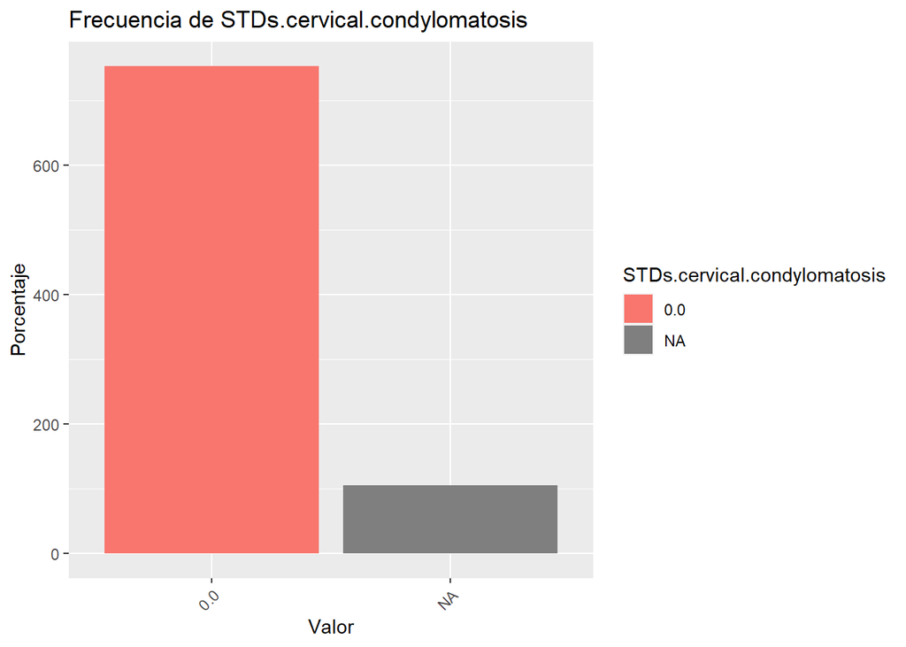

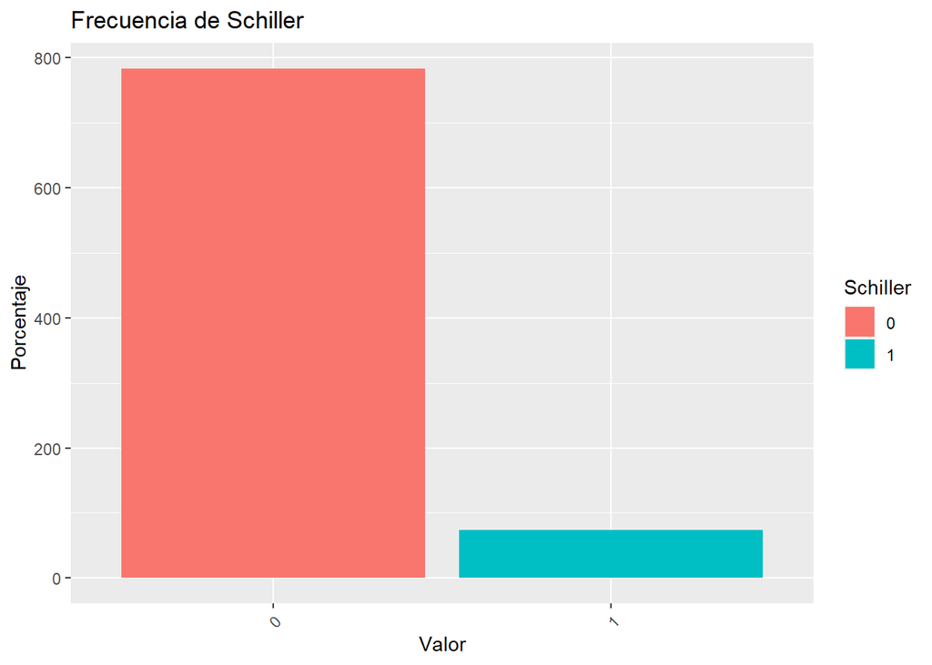

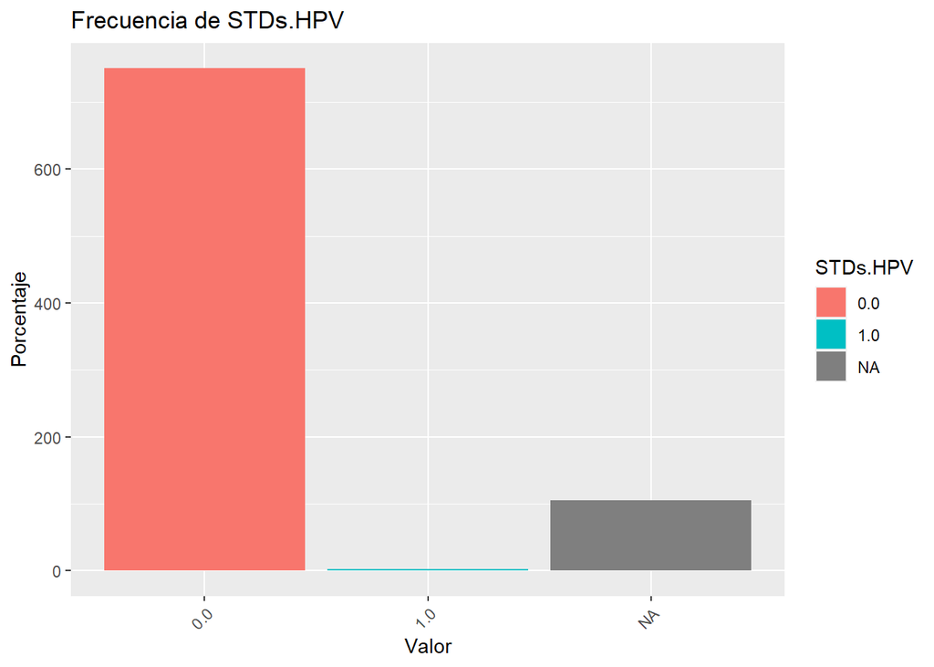

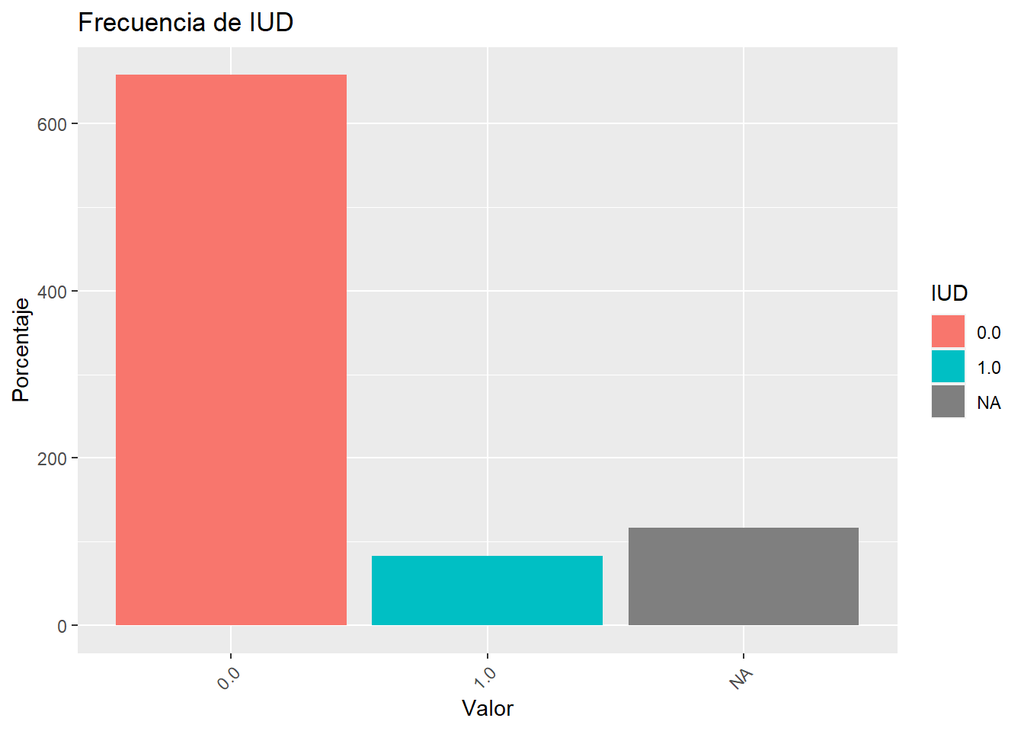

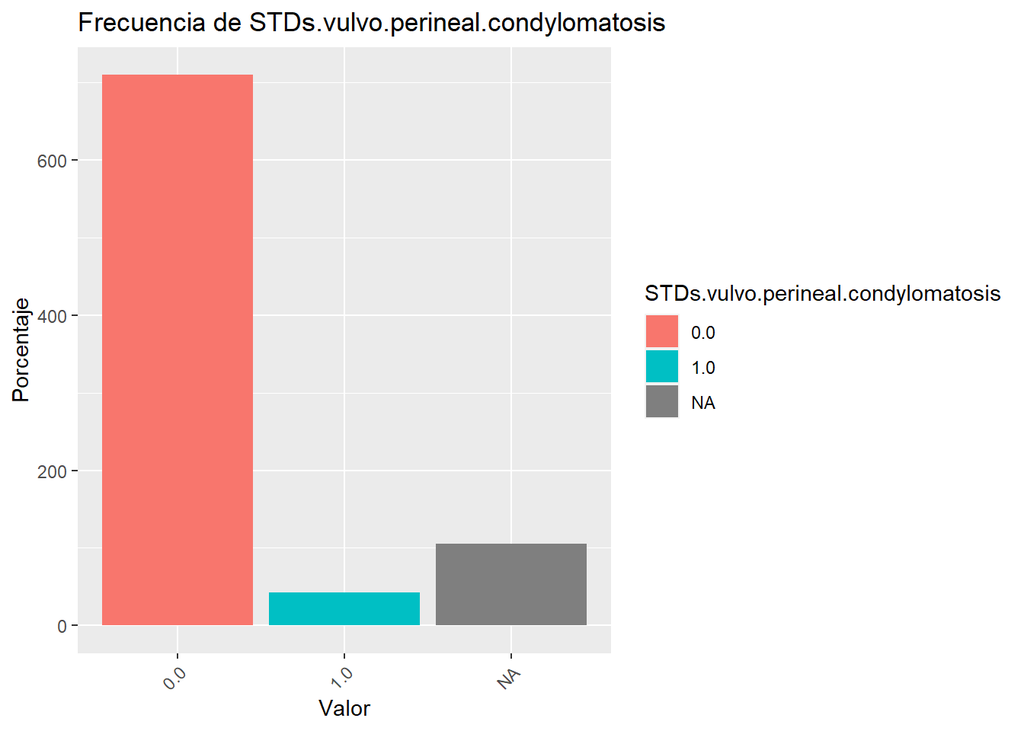

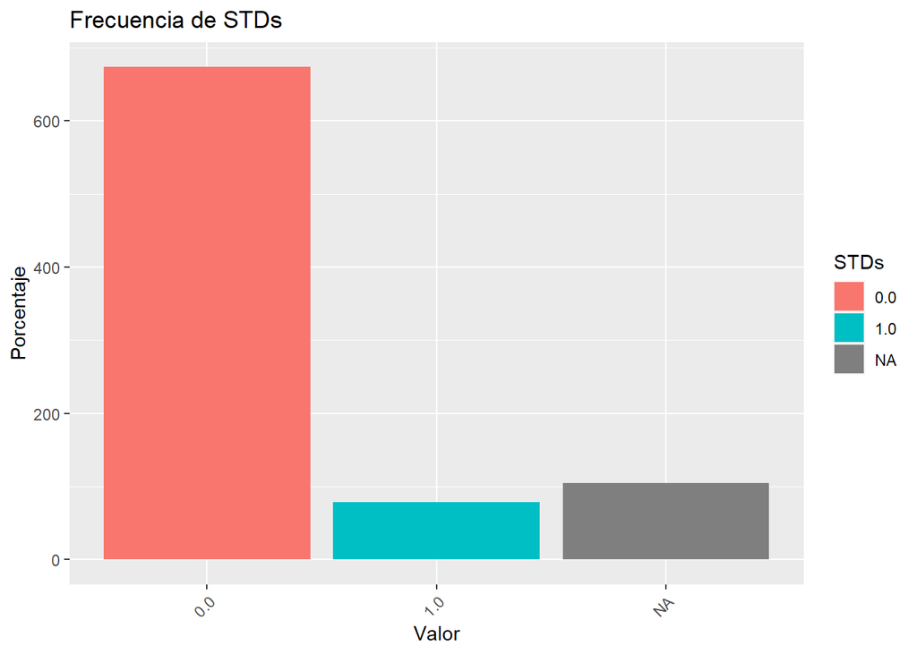

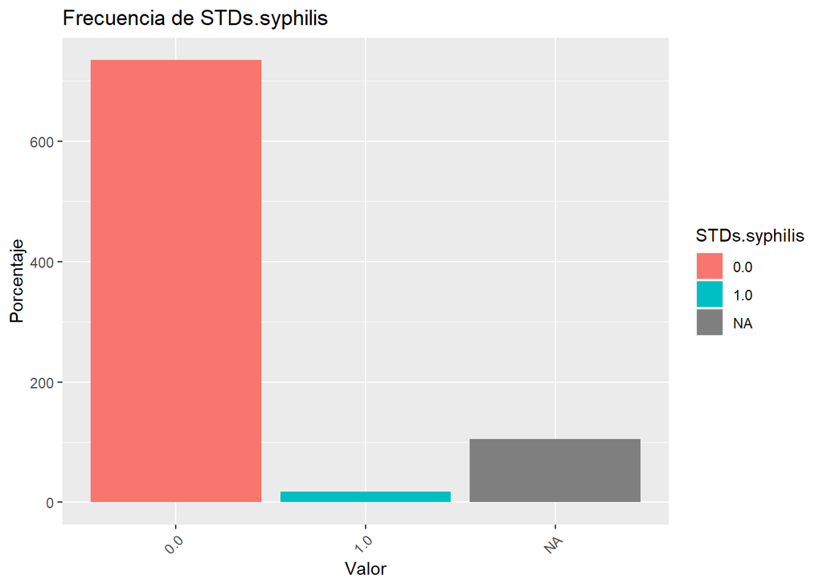

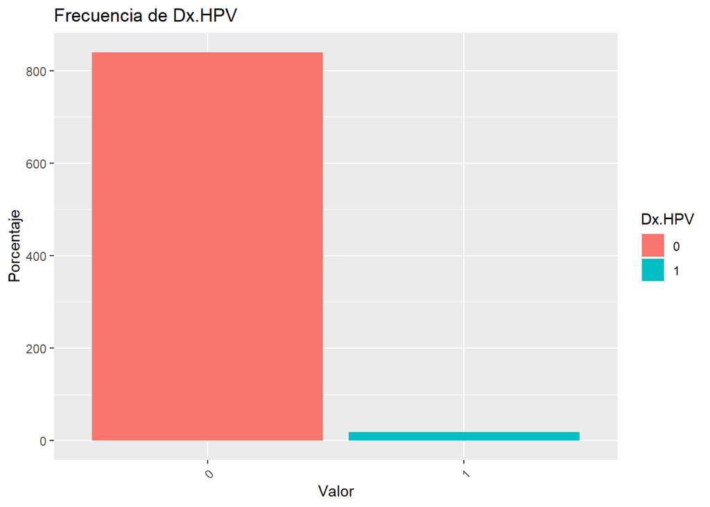

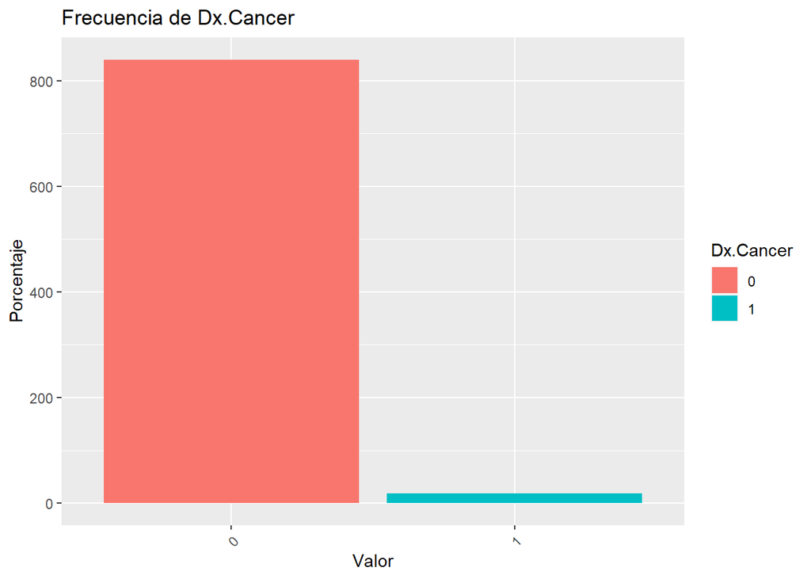

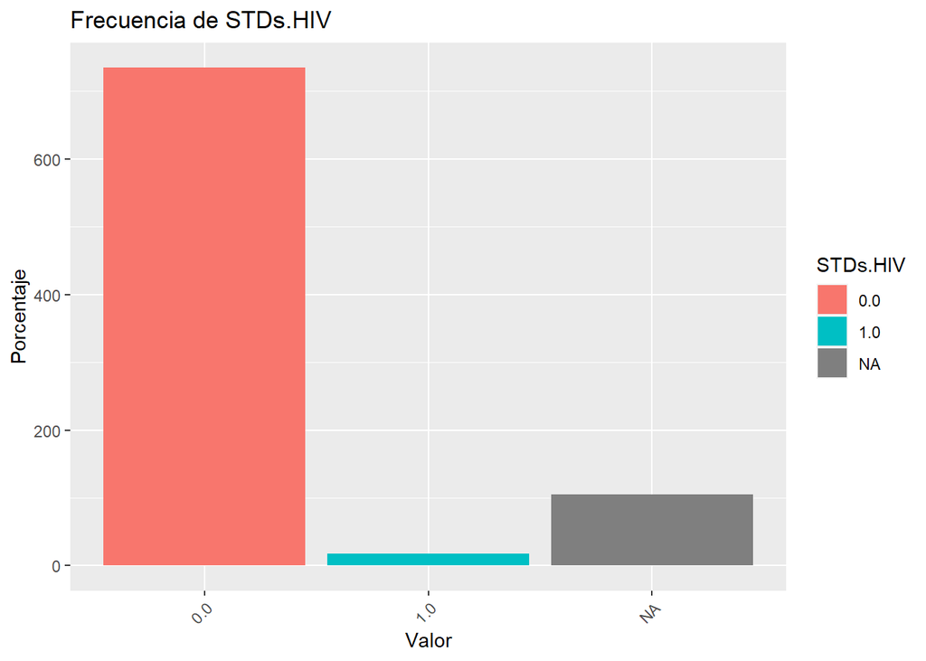

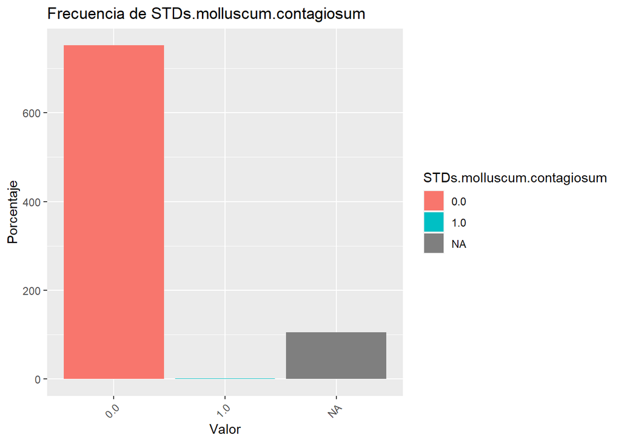

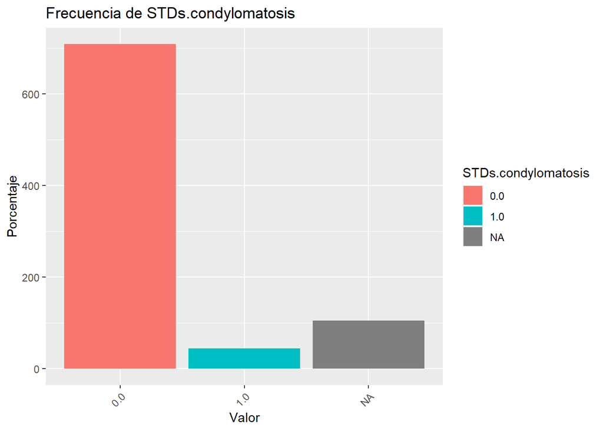

[11 more figures not shown]

```r
# Crear una función para generar gráficas de barras para las variables categóricas
graficar_barras <- function(data, variable) {
  # Calcular la tabla de frecuencias
  tabla_frecuencia <- prop.table(table(data[[variable]])) * 100

  # Ordenar las categorías de mayor a menor frecuencia
  orden <- names(sort(-tabla_frecuencia))
  data[[variable]] <- factor(data[[variable]], levels = orden)

  # Crear la gráfica de barras
  p <- ggplot(data = data, aes(x = .data[[variable]], fill = .data[[variable]])) +
    geom_bar() +
    labs(title = paste("Frecuencia de", variable), x = "Valor", y = "Porcentaje") +
    theme(axis.text.x = element_text(angle = 45, hjust = 1))

  return(p)
}

# Crear una ventana gráfica para mostrar las gráficas de barras
par(mfrow = c(6, 4))  # Configuramos el diseño para mostrar varias gráficas en una sola ventana

# Generar las gráficas de barras para las variables categóricas cualitativas
for (variable in categorias_cualitativas) {
  grafica <- graficar_barras(df, variable)
  print(grafica)
}
```

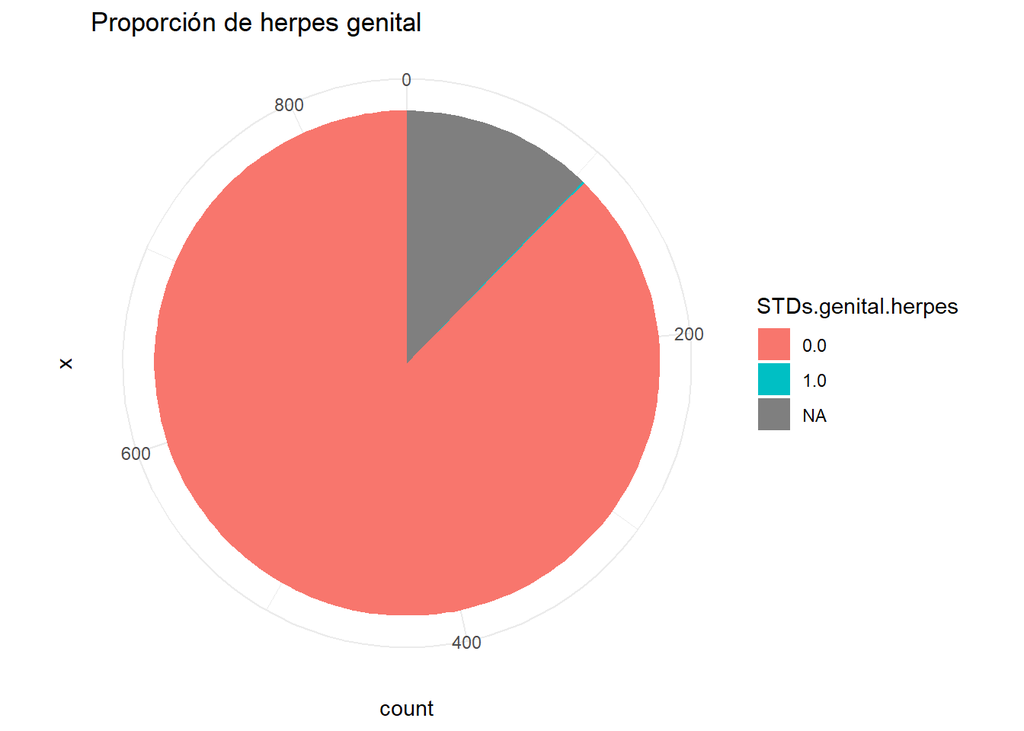

```r
ggplot(df, aes(x = "", fill = `STDs.genital.herpes`)) +
  geom_bar(width = 1) +
  coord_polar(theta = "y") +
  labs(title = "Proporción de herpes genital", fill = "STDs.genital.herpes") +
  theme_minimal()
```

Vemos que la proporcion de herpes genital en su mayoria esta lleno de 0.0 y tambien unos cuantos NA y muy pocos 1.0 lo que significa que tenemos una cantidad de gente que tiene relacion con esta enfermedad o que prefiere no decirlo.

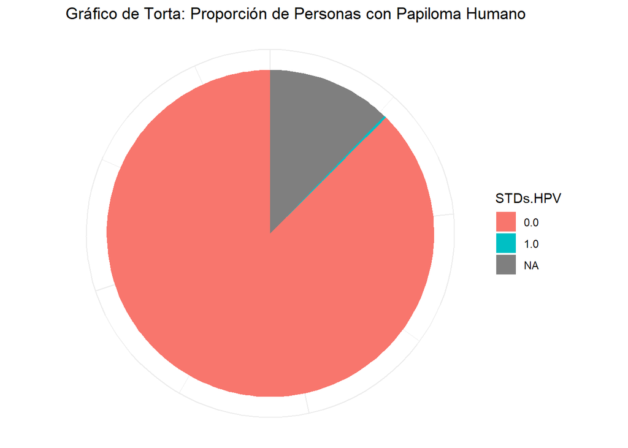

```r
data_categoricas <- df[, c(categorias_cualitativas)]

ggplot(data_categoricas, aes(x = "", fill = `STDs.HPV`)) +
  geom_bar(width = 1) +
  coord_polar("y", start = 0) +
  labs(title = "Gráfico de Torta: Proporción de Personas con Papiloma Humano", x = NULL, y = NULL) +
  theme_minimal() +
  theme(axis.text.x = element_blank())
```

Este grafico de pie es similar al anterior la gran mayoria son 0.0 y bastantes NA y uy pocos 1.0

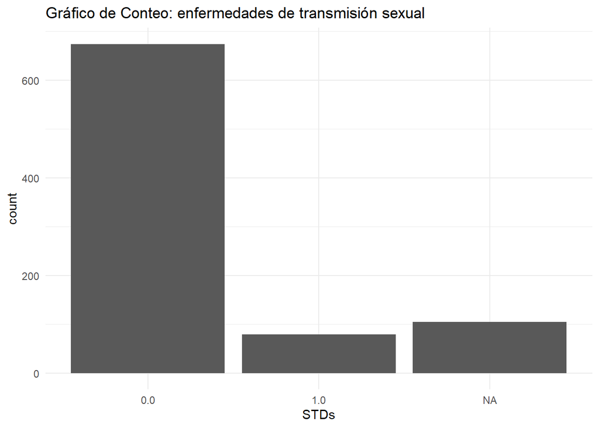

```r
ggplot(data_categoricas, aes(x = `STDs`)) +
  geom_bar() +
  labs(title = "Gráfico de Conteo: enfermedades de transmisión sexual", x = "STDs") +
  theme_minimal()
```

De igual manera con este tipo pero ahora habla en general por lo que podemos decir que la mayoria de variables tienen estas proporciones que hay que tomar en cuenta, la mayoria entran por este timpo de enfermedades.

### 6. Determine el comportamiento a seguir con los valores faltantes. Explique si necesita remover alguna variable por la cantidad de valores faltantes que tiene. ¿Es factible eliminar todos los valores faltantes de todas las variables?

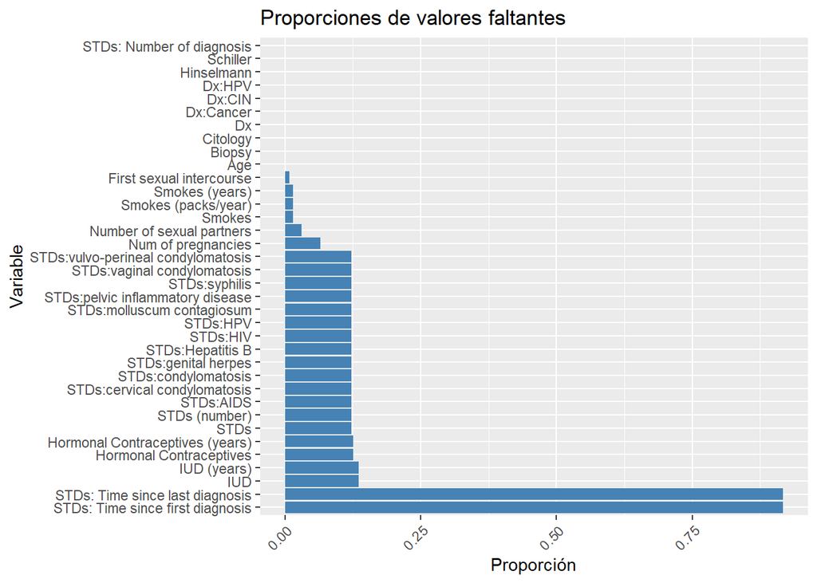

```r
# Cargar las librerías necesarias
library(dplyr)
library(ggplot2)

# Calcular las proporciones de valores faltantes en cada columna del DataFrame 'data'
missing_proportions <- colSums(is.na(data)) / nrow(data)

# Convertir las proporciones en un data frame y ordenar en orden descendente
missing_df <- data.frame(variable = names(missing_proportions), proportion = missing_proportions) %>%
  arrange(desc(proportion))

# Crear la gráfica de barras
ggplot(missing_df, aes(x = reorder(variable, -proportion), y = proportion)) +
  geom_bar(stat = "identity", fill = "steelblue") +
  labs(title = "Proporciones de valores faltantes", x = "Variable", y = "Proporción") +
  theme(axis.text.x = element_text(angle = 45, hjust = 1)) +
  coord_flip()
```

Tenemos que STDs: time since las diagnosis y STDs: time since first diagnosis tiene muchos valores nulos por lo que se pueden eliminar varios de ellos, otros tipos de que tienen varios valores nudos son aproximadamente 18, lo que es una desgracia ya que tenemos que eliminar este tipo de datos ya que no nos va a servir de nada y pueden generar algun sesgo.

### 7. Estudie si es posible hacer transformaciones en las variables categóricas para incluirlas en el PCA, ¿valdrá la pena?

En el análisis de componentes principales (PCA), generalmente las variables categóricas no se pueden incluir directamente. Sin embargo, se pueden realizar transformaciones para representar estas variables en el espacio de PCA.

Una posible forma de hacerlo es utilizando el enfoque de “one-hot encoding” o “dummy encoding”, donde cada categoría de una variable categórica se convierte en una nueva variable binaria (0 o 1).

Otra opción es utilizar técnicas de reducción de dimensionalidad específicas para variables categóricas, como el Análisis de Correspondencias Múltiples (MCA), que es similar al PCA pero diseñado para variables categóricas.

Es importante evaluar si estas transformaciones son adecuadas para el conjunto de datos y si aportan información relevante en el análisis de componentes principales.

### 8. Estudie si es conveniente hacer un Análisis de Componentes Principales. Recuerde que puede usar el índice KMO y el test de esfericidad de Bartlett. Haga un análisis de componentes principales con las variables numéricas, discuta los resultados e interprete los componentes.

```r
library(psych)
train_cuanti_numeric <- sapply(numeric_data, as.numeric)
rcor<-cor(train_cuanti_numeric,use = "pairwise.complete.obs")
det(rcor)#Si el determinante de la matriz de correlación es cercano a 0 significa que hay multicolinealidad
```

```
## [1] 0.0002060142
```

Dado que este factor es muy cercano a 0, esto significa que hay multicolinealidad.

```r
KMO(as.matrix(train_cuanti_numeric))
```

```
## Kaiser-Meyer-Olkin factor adequacy
## Call: KMO(r = as.matrix(train_cuanti_numeric))
## Overall MSA =  0.57
## MSA for each item =
##                             Age       Number.of.sexual.partners
##                            0.48                            0.64
##        First.sexual.intercourse              Num.of.pregnancies
##                            0.28                            0.51
##                  Smokes..years.             Smokes..packs.year.
##                            0.56                            0.51
## Hormonal.Contraceptives..years.                     IUD..years.
##                            0.58                            0.45
##                   STDs..number.       STDs..Number.of.diagnosis
##                            0.50                            0.51
##                       Dx.Cancer                          Dx.CIN
##                            0.59                            0.28
##                          Dx.HPV                              Dx
##                            0.72                            0.53
##                      Hinselmann                        Schiller
##                            0.78                            0.68
##                        Citology                          Biopsy
##                            0.77                            0.75
```

```r
cortest.bartlett(train_cuanti_numeric)
```

```
## R was not square, finding R from data
```

```
## $chisq
## [1] 7215.845
##
## $p.value
## [1] 0
##
## $df
## [1] 153
```

Dado que el valor p es extremadamente pequeño, significa que las variables en “train_cuanti_numeric” están correlacionadas entre sí y, por lo tanto, los datos son adecuados para un análisis de factores.

```r
install.packages("corrplot")
library(corrplot)
```

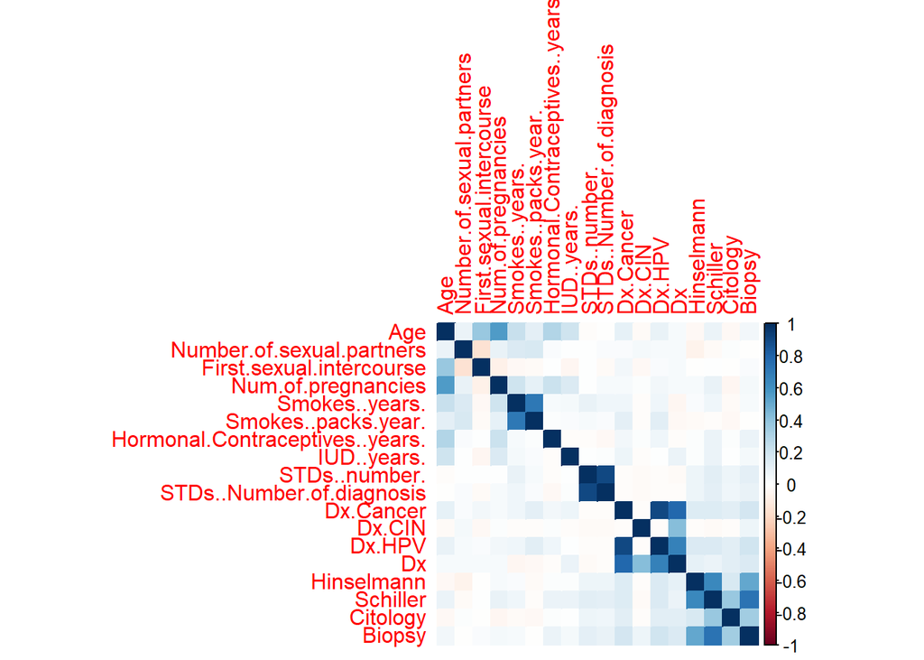

```r
# Verificar si hay filas con valores faltantes en tu conjunto de datos
filas_completas <- complete.cases(train_cuanti_numeric)

# Crear un nuevo conjunto de datos con solo las filas completas
datos_completos <- train_cuanti_numeric[filas_completas, ]

# Calcular la matriz de correlación del conjunto de datos completo
cor_matrix <- cor(datos_completos, method = "pearson")

# Graficar la matriz de correlación sin valores faltantes
corrplot(cor_matrix, method = "color")
```

```r
compPrinc<-prcomp(datos_completos, scale = T)
compPrinc
```

```
## Standard deviations (1, .., p=18):
##  [1] 1.7655874 1.4928301 1.4545540 1.3264041 1.2224644 1.1063872 1.0361326
##  [8] 1.0093132 0.9522402 0.9063774 0.8502468 0.6622256 0.5368371 0.5002771
## [15] 0.4703456 0.4108051 0.3101425 0.2321629
##
## Rotation (n x k) = (18 x 18):
##                                        PC1         PC2         PC3         PC4
## Age                             0.13618490 -0.10970666  0.42814223 -0.25756755
## Number.of.sexual.partners       0.03449747 -0.06346626  0.19488465  0.07867913
## First.sexual.intercourse        0.03832286 -0.04319488  0.05021559 -0.11715801
## Num.of.pregnancies              0.11750743 -0.05435611  0.39982479 -0.20319053
## Smokes..years.                  0.10288998 -0.03168342  0.49127842  0.08688436
## Smokes..packs.year.             0.08725337 -0.09527004  0.43286242  0.13359634
## Hormonal.Contraceptives..years. 0.08656610 -0.02810484  0.18691336 -0.21209681
## IUD..years.                     0.07960392 -0.02416970  0.13624441 -0.08935388
## STDs..number.                   0.09012779  0.39038567  0.14585881  0.50665902
## STDs..Number.of.diagnosis       0.08686497  0.38311270  0.14846356  0.51091675
## Dx.Cancer                       0.43347896 -0.32423045 -0.09618613  0.17999851
## Dx.CIN                          0.07402738 -0.11371855 -0.08611691  0.07951654
## Dx.HPV                          0.42264752 -0.30331214 -0.08544293  0.17071490
## Dx                              0.38248122 -0.32492580 -0.18589571  0.19741860
## Hinselmann                      0.30265426  0.29591478 -0.09992126 -0.20798243
## Schiller                        0.35921611  0.36561754 -0.04510023 -0.26559980
## Citology                        0.21847556  0.19344705 -0.12073933 -0.07916416
## Biopsy                          0.36140585  0.30690339 -0.07530692 -0.22235982
##                                          PC5           PC6           PC7
## Age                              0.396888122 -0.0503653952  0.0794106657
## Number.of.sexual.partners       -0.208677176  0.3777810566 -0.1152442971
## First.sexual.intercourse         0.367454661 -0.5278969168  0.4690871449
## Num.of.pregnancies               0.236937180  0.2784787112 -0.1541981612
## Smokes..years.                  -0.391518998 -0.1317759132  0.1638067600
## Smokes..packs.year.             -0.452853117 -0.1786026192  0.1605457810
## Hormonal.Contraceptives..years.  0.221455361  0.1442598613 -0.0646348830
## IUD..years.                      0.141043962  0.1825999536 -0.3486030728
## STDs..number.                    0.241213429 -0.0016452130  0.0007154148
## STDs..Number.of.diagnosis        0.247367978  0.0332411848 -0.0255703228
## Dx.Cancer                        0.031021863 -0.1546585422 -0.1796636416
## Dx.CIN                           0.032380371  0.5578631558  0.6731839239
## Dx.HPV                           0.004918267 -0.1604543806 -0.1855902341
## Dx                               0.096205890  0.1719464390  0.1469843113
```

[output cut: 65 more lines]

```
## Num.of.pregnancies               0.030493069  0.041017151
## Smokes..years.                  -0.056257426  0.015452494
## Smokes..packs.year.              0.035138012 -0.064129905
## Hormonal.Contraceptives..years. -0.025906931 -0.023159696
## IUD..years.                     -0.014033065 -0.014957366
## STDs..number.                    0.699874784 -0.059754935
## STDs..Number.of.diagnosis       -0.696644786  0.059965113
## Dx.Cancer                        0.075658338  0.766509597
## Dx.CIN                          -0.011584454  0.197477017
## Dx.HPV                          -0.097446576 -0.415339677
## Dx                               0.024691453 -0.429326080
## Hinselmann                       0.004227913  0.008535555
## Schiller                         0.019281188 -0.016226806
## Citology                        -0.001115962  0.026907293
## Biopsy                          -0.028466973 -0.009290758
```

```r
summary(compPrinc)
```

```
## Importance of components:
##                           PC1    PC2    PC3     PC4     PC5     PC6     PC7
## Standard deviation     1.7656 1.4928 1.4546 1.32640 1.22246 1.10639 1.03613
## Proportion of Variance 0.1732 0.1238 0.1175 0.09774 0.08302 0.06801 0.05964
## Cumulative Proportion  0.1732 0.2970 0.4145 0.51227 0.59530 0.66330 0.72294
##                           PC8     PC9    PC10    PC11    PC12    PC13   PC14
## Standard deviation     1.0093 0.95224 0.90638 0.85025 0.66223 0.53684 0.5003
## Proportion of Variance 0.0566 0.05038 0.04564 0.04016 0.02436 0.01601 0.0139
## Cumulative Proportion  0.7795 0.82992 0.87556 0.91572 0.94008 0.95609 0.9700
##                           PC15    PC16    PC17    PC18
## Standard deviation     0.47035 0.41081 0.31014 0.23216
## Proportion of Variance 0.01229 0.00938 0.00534 0.00299
## Cumulative Proportion  0.98229 0.99166 0.99701 1.00000
```

```r
compPrincPCA<-PCA(datos_completos[,-1],ncp=ncol(datos_completos[,-1]), scale.unit = T)
```

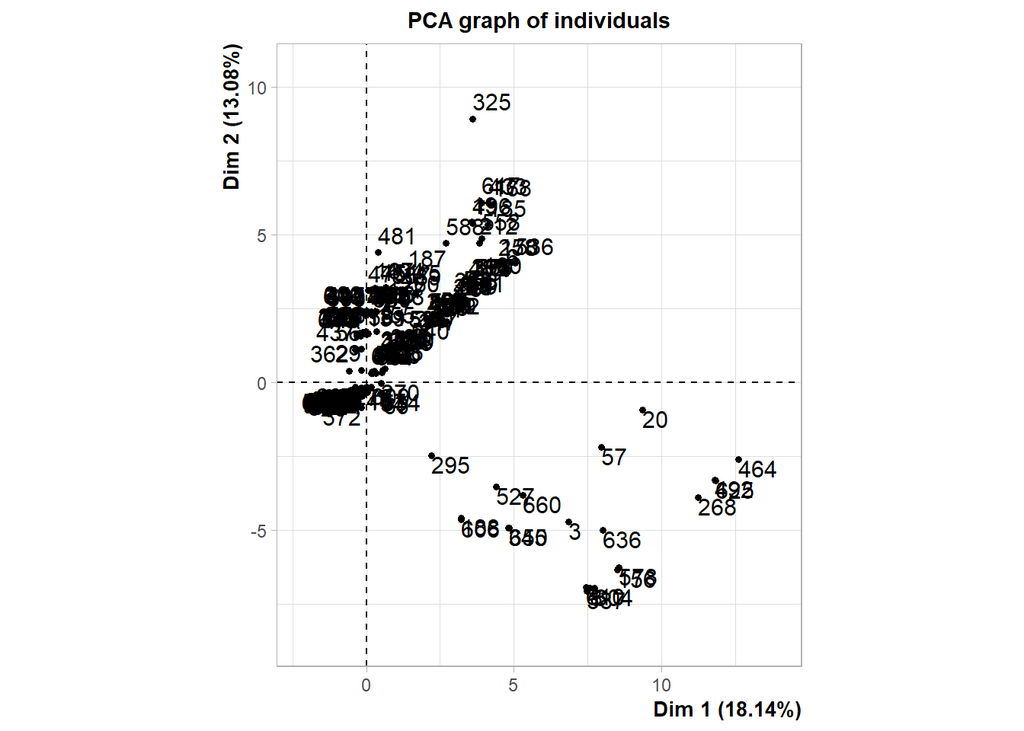

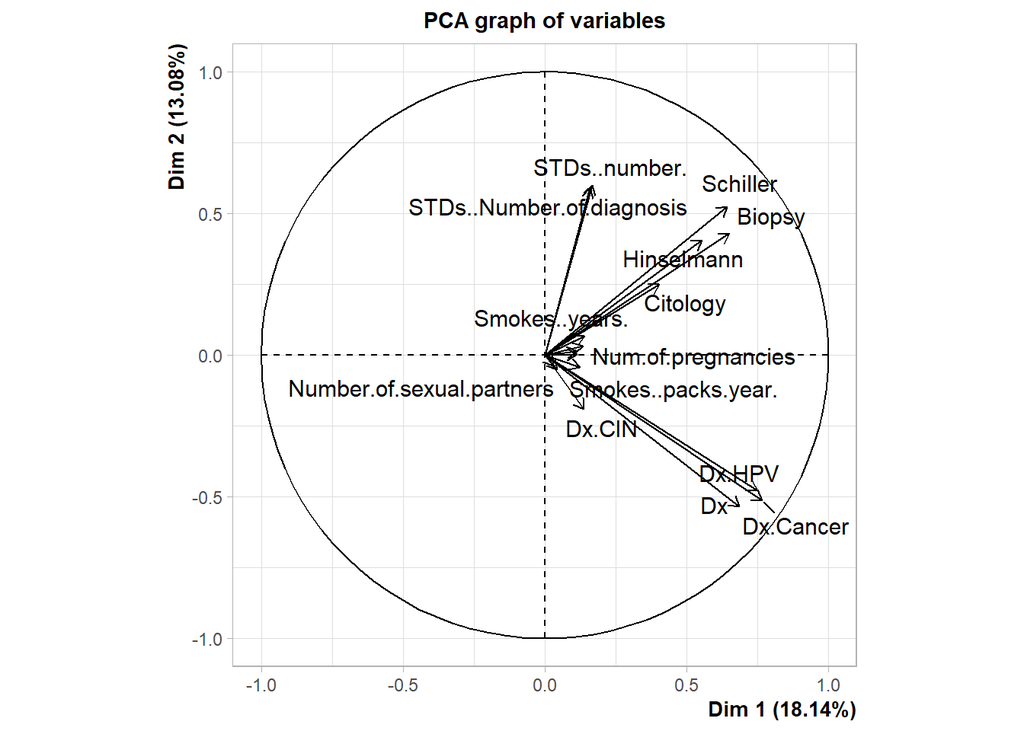

```r
summary(compPrincPCA)
```

```
##
## Call:
## PCA(X = datos_completos[, -1], scale.unit = T, ncp = ncol(datos_completos[,
##      -1]))
##
##
## Eigenvalues
##                        Dim.1   Dim.2   Dim.3   Dim.4   Dim.5   Dim.6   Dim.7
## Variance               3.084   2.223   1.937   1.679   1.233   1.146   1.046
## % of var.             18.141  13.079  11.394   9.876   7.252   6.742   6.155
## Cumulative % of var.  18.141  31.220  42.614  52.490  59.742  66.484  72.639
##                        Dim.8   Dim.9  Dim.10  Dim.11  Dim.12  Dim.13  Dim.14
## Variance               1.016   0.871   0.801   0.706   0.438   0.276   0.224
## % of var.              5.978   5.123   4.711   4.152   2.576   1.621   1.315
## Cumulative % of var.  78.617  83.740  88.451  92.603  95.179  96.800  98.115
##                       Dim.15  Dim.16  Dim.17
## Variance               0.170   0.096   0.054
## % of var.              0.999   0.566   0.320
## Cumulative % of var.  99.114  99.680 100.000
##
## Individuals (the 10 first)
##                                     Dist    Dim.1    ctr   cos2    Dim.2    ctr
## 1                               |  1.820 | -0.758  0.028  0.173 | -0.407  0.011
## 2                               |  2.004 | -0.811  0.032  0.164 | -0.338  0.008
## 3                               | 20.031 |  6.855  2.281  0.117 | -4.733  1.508
## 4                               |  3.954 | -0.316  0.005  0.006 | -0.353  0.008
## 5                               |  2.341 | -0.671  0.022  0.082 | -0.440  0.013
## 6                               | 11.180 |  4.733  1.087  0.179 |  3.674  0.909
## 7                               |  4.678 | -0.368  0.007  0.006 | -0.398  0.011
## 8                               | 11.227 |  7.561  2.775  0.454 | -6.955  3.257
## 9                               |  3.436 | -0.512  0.013  0.022 | -0.431  0.013
## 10                              |  2.044 | -0.547  0.015  0.072 | -0.312  0.007
##                                   cos2    Dim.3    ctr   cos2
## 1                                0.050 | -0.225  0.004  0.015 |
## 2                                0.028 | -0.663  0.034  0.109 |
## 3                                0.056 | 15.105 17.633  0.569 |
## 4                                0.008 |  0.094  0.001  0.001 |
## 5                                0.035 | -0.498  0.019  0.045 |
## 6                                0.108 |  3.961  1.213  0.126 |
## 7                                0.007 | -0.492  0.019  0.011 |
```

[output cut: 12 more lines]

```
## IUD..years.                     |  0.115  0.425  0.013 |  0.003  0.000  0.000 |
## STDs..number.                   |  0.167  0.901  0.028 |  0.600 16.207  0.360 |
## STDs..Number.of.diagnosis       |  0.160  0.830  0.026 |  0.590 15.678  0.349 |
## Dx.Cancer                       |  0.768 19.113  0.589 | -0.512 11.798  0.262 |
##                                  Dim.3    ctr   cos2
## Number.of.sexual.partners        0.359  6.663  0.129 |
## First.sexual.intercourse        -0.136  0.954  0.018 |
## Num.of.pregnancies               0.323  5.398  0.105 |
## Smokes..years.                   0.787 31.942  0.619 |
## Smokes..packs.year.              0.776 31.101  0.602 |
## Hormonal.Contraceptives..years.  0.071  0.260  0.005 |
## IUD..years.                      0.095  0.461  0.009 |
## STDs..number.                    0.340  5.955  0.115 |
## STDs..Number.of.diagnosis        0.344  6.116  0.118 |
## Dx.Cancer                        0.087  0.394  0.008 |
```

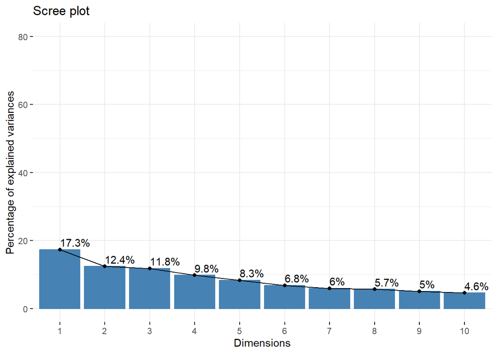

```r
fviz_eig(compPrinc, addlabels = TRUE, ylim = c(0, 80))
```

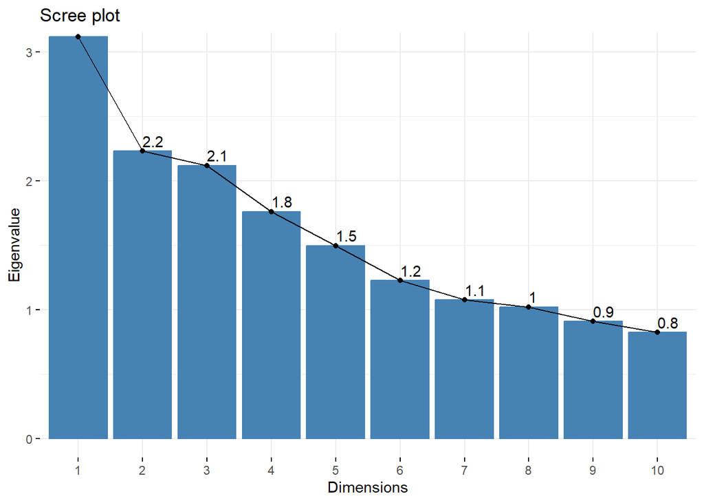

```r
fviz_eig(compPrinc, addlabels = TRUE, choice = c("eigenvalue"), ylim = c(0, 3))
```

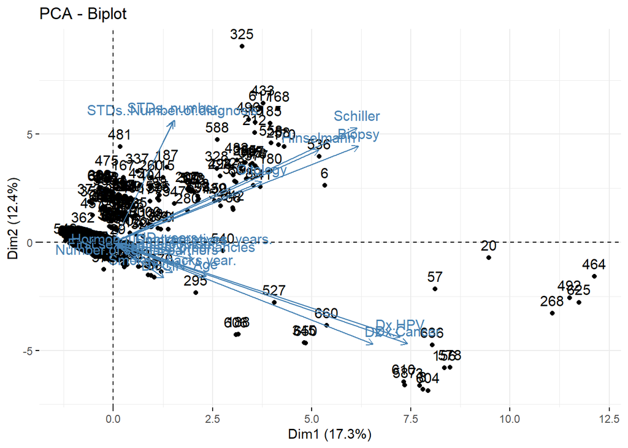

```r
fviz_pca_biplot(compPrinc,repel = F)
```

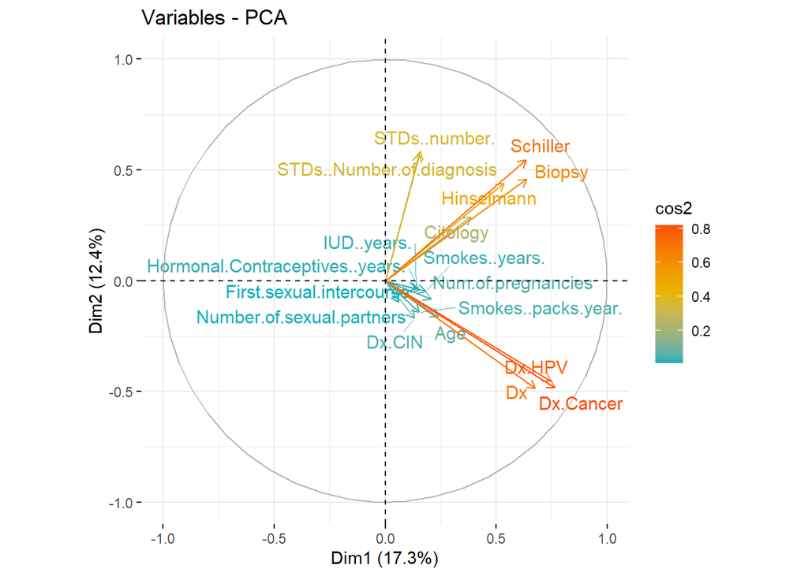

```r
# En la siguiente gráfica se ilustra la calidad de la representación de los componentes en las dos primeras dimensiones.
fviz_pca_var(compPrinc, col.var = "cos2",
             gradient.cols = c("#00AFBB", "#E7B800", "#FC4E07"),
             repel = TRUE # Avoid text overlapping
)
```